# Exploring Sleep and Exercise in the BRFSS Data

## Setup

### Load packages

```r
library(ggplot2)
library(dplyr)
```

### Load data

```r
load("brfss2013.RData")
```

## Part 1: Data

This analysis examines data from the 2013 Behavioral Risk Factor Surveillance System (BRFSS) dataset. It contains data from non-institutionalized adults of age 18 or older residing in one of the 50 US states, DC, Puerto Rico, or Guam. It examines behavioral preventative health practices and risk factors that may lead to chronic diseases.

The survey was conducted via landline and cellular telephones, with samples randomly dialed. Additionally, when conducting the landline survey, a randomly selected household member was asked to take part in the survey.

Since this study is observational, without random assignment, only association between variables can be established, not causality. The data were collected from a random sample, however, so these data are indeed generalizable to non-institutionalized adults of age 18 or older residing in one of the 50 US states, DC, Puerto Rico, or Guam.

It should be kept in mind that the responses were all self-report data, which are often prone to bias from respondents or inacurracies from incorrect recall. There were also many variables that had data missing because the respondents didn’t know or chose not to respond, and this non-response may indicate something meaningful about these respondents compared to the others.

## Part 2: Research questions

With an interest in the importance of sleep, I wanted to examine the association between sleep and quality of life. To do this, I chose to examine sleep and income levels (Q1), as well as health status and sex (Q2). Finally, as I’m also a fond exerciser, I was curious if sex and weight status are associated with time spent exercising (Q3).

**Research Question 1:** Is there an association between income and the amount of sleep respondents get in a 24-hour period?

**Research Question 2:** Is there an association between the amount of sleep respondents get in a 24-hour period and both sex and their reported health status?

**Research Question 3:** Is there an association between the amount of exercise respondents partake in and both sex and overweight/obesity status?

## Part 3: Exploratory Data Analysis

**Research Question 1:** Is there an association between income and the amount of sleep respondents get in a 24-hour period?

To start my analysis, I will begin by exploring sleptim1 - the number of hours of sleep respondents said they get in a 24-hour period on average.

I begin with a boxpolot to examine the spread of the data

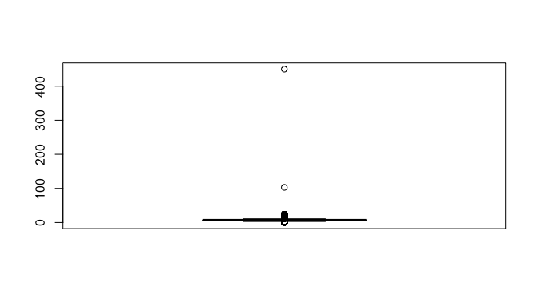

```r
boxplot(data = brfss2013, x=brfss2013$sleptim1)
```

This output clearly illustrates that there are some extreme values in the dataset, around 100 and greater than 400, as well as 0. The only values included in the codebook are values from 1 to 24 as well as “Don’t Know”" or “Refused” for those who didn’t know or chose not to respond, respectively. Since there are only 24 hours in a day, a number greater than 24 would not make sense.

Filtering values greater than 24 and less than 1 in the dataset confirms that there are these three points which are not within the codebook’s range of possible values:

```r
brfss2013 %>% filter(sleptim1>24 | sleptim1<1) %>% group_by(sleptim1) %>% summarise(n())
```

```
## # A tibble: 3 x 2
##   sleptim1 `n()`
##      <int> <int>
## 1        0     1
## 2      103     1
## 3      450     1
```

Thus, these values are likely to have been errors, and I will eliminate them from my analysis. Below is a boxplot of the data without the extreme values:

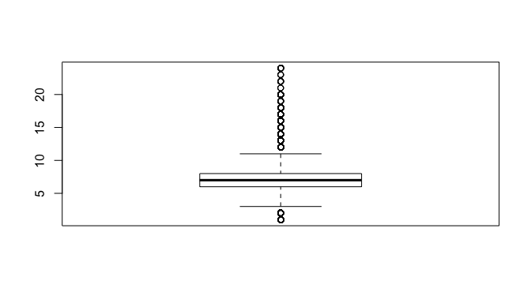

```r
sleep_clean <- brfss2013 %>% filter(sleptim1 <= 24, sleptim1>0)
boxplot(data = sleep_clean, x=sleep_clean$sleptim1)
```

The data are right skewed, with fewer data points for the longer hours. A histogram and summary statistics help provide a closer look at the distribution:

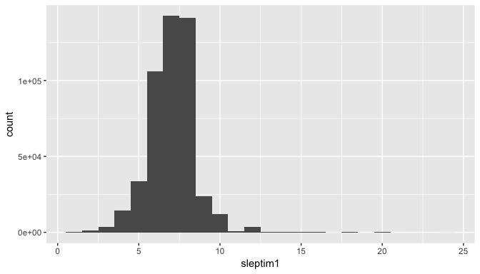

```r
ggplot(data = sleep_clean, aes(x= sleptim1)) +geom_histogram(binwidth = 1)
```

```r
sleep_clean %>% summarise(min = min(sleptim1), mean = round(mean(sleptim1),2), med = median(sleptim1), sd = round(sd(sleptim1),2), max = max(sleptim1))
```

```
##   min mean med   sd max
## 1   1 7.05   7 1.47  24
```

While the data appear to be mostly symmetrical in this view, with not much variability (as also evidenced by the low standard deviation), the data are in fact right skewed since there are still data points in the higher hours. This is also evidenced by the fact that the mean is slightly higher than the median.

Most research I have done on sleep indicates that 7-9 hours is the ideal range for most people. I will create a categorical variable to simplify the analysis, and I will divide the data into three levels: less than 7 hours of sleep (“minimal”), 7 to 9 hours of sleep (“optimal”), or more than 9 hours of sleep (“maximum”):

```r
sleep_clean <- sleep_clean %>% mutate(sleepgroup = ifelse(sleptim1<7 ,"minimal", ifelse(sleptim1<=9, "optimal", "maximum")))
```

I will also include summary statistics for each group, a frequency table, and a frequency plot:

```r
sleep_clean %>% group_by(sleepgroup) %>% summarise(count = n(), mean = mean(sleptim1), median = median(sleptim1), sd = sd(sleptim1))
```

```
## # A tibble: 3 x 5
##   sleepgroup  count      mean median        sd
##        <chr>  <int>     <dbl>  <dbl>     <dbl>
## 1    maximum  18320 10.962118     10 1.7943222
## 2    minimal 158694  5.509181      6 0.8197116
## 3    optimal 307371  7.613923      8 0.6260069
```

The medians for the minimal and optimal groups are slightly higher than the means, indicating a slight left skew, while the opposite is true for the maximum group. Additionally, the spread of the data (standard deviation) of the maximum group is larger than both the minimal and optimal groups, which aligns with the higher variability of the higher values, as evidenced by the boxplot and histogram.

```r
sleep_clean %>% group_by(sleepgroup) %>% summarise(n = n()) %>% mutate(freq = n/sum(n))
```

```
## # A tibble: 3 x 3
##   sleepgroup      n       freq
##        <chr>  <int>      <dbl>
## 1    maximum  18320 0.03782115
## 2    minimal 158694 0.32761956
## 3    optimal 307371 0.63455929
```

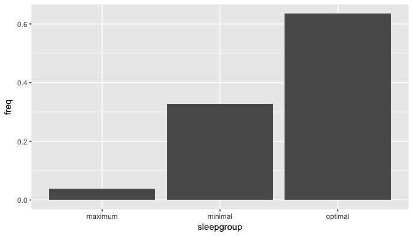

```r
sleep_clean %>% group_by(sleepgroup) %>% summarise(n = n()) %>% mutate(freq = n/sum(n)) %>% ggplot(aes(x=sleepgroup, y = freq)) + geom_bar(stat="identity")
```

The frequency table and plot illustrate that in a 24-hour period, almost two thirds of respondents get “optimal” levels of sleep, about a third get “minimal” hours of sleep, and very few people sleep more than 9 hours (“maximum”) on average.

Now I will examine the income variable using my updated sleep_clean dataset with a frequency table and plot:

```r
sleep_clean %>% group_by(income2) %>% summarise(n = n()) %>% mutate(freq = n/sum(n))
```

```
## # A tibble: 9 x 3
##             income2      n       freq
##              <fctr>  <int>      <dbl>
## 1 Less than $10,000  24649 0.05088721
## 2 Less than $15,000  26112 0.05390753
## 3 Less than $20,000  34211 0.07062770
## 4 Less than $25,000  41185 0.08502534
## 5 Less than $35,000  48327 0.09976981
## 6 Less than $50,000  61068 0.12607327
## 7 Less than $75,000  64916 0.13401736
## 8   $75,000 or more 115455 0.23835379
## 9              <NA>  68462 0.14133799
```

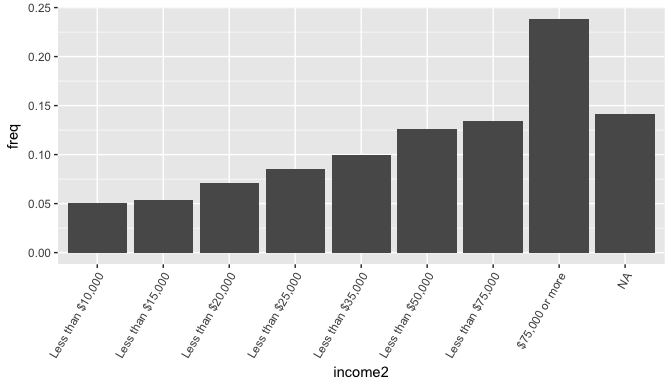

```r
sleep_clean %>% group_by(income2) %>% summarise(n = n()) %>% mutate(freq = n/sum(n)) %>% ggplot(aes(x= income2, y=freq)) +geom_bar(stat="identity") + theme(axis.text.x = element_text(angle = 60, hjust = 1))
```

The data of income in this dataset are left skewed, with almost a quarter of respondents having incomes equal to or greater than $75,000. There are also a significant number of people who refused to respond, didn’t know or whose data were missing (“NA”). Given the size of this group, it’s important to include these responses as there may be something meaningful about respondents in this group.

To investigate if there is a relationship between income and hours of sleep, I will explore the data through a segmented, relative frequency barplot:

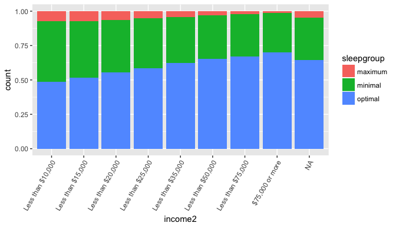

```r
 ggplot(data = sleep_clean, aes(x= income2, fill = sleepgroup)) + geom_bar(position = "fill") + theme(axis.text.x = element_text(angle = 60, hjust = 1))
```

The data here show that there is indeed a relationship between income and the range of hours of sleep: as incomes increase, the percentage of people who get the “optimal” 7-9 hours of sleep also increases. Similarly as incomes increase, the percentage of people who get the “minimal” less than 7 hours of sleep decreases. It’s interesting to note that the NA group appears to match the “Less than $35,000” group most closely.

Further research into the significance of these associations and potential causual implications is warranted.

**Research Question 2:** Is there an association between the amount of sleep respondents get in a 24-hour period and both sex and their reported health status?

I will start by examining the genhlth variable, using the sleep_clean dataset to look at the relative frequencies of each health status:

```r
sleep_clean %>% group_by(genhlth) %>% summarise(n = n()) %>% mutate(freq = n/sum(n))
```

```
## # A tibble: 6 x 3
##     genhlth      n        freq
##      <fctr>  <int>       <dbl>
## 1 Excellent  84821 0.175110707
## 2 Very good 157833 0.325842047
## 3      Good 148299 0.306159357
## 4      Fair  65012 0.134215552
## 5      Poor  26639 0.054995510
## 6      <NA>   1781 0.003676827
```

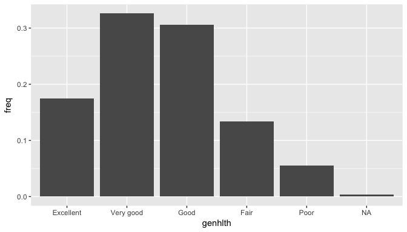

```r
 sleep_clean %>% group_by(genhlth) %>% summarise(n = n()) %>% mutate(freq = n/sum(n)) %>% ggplot(aes(x=genhlth, y=freq)) + geom_bar(stat = "identity")
```

There was a small sample of people that didn’t know or didn’t answer the question (“NA”). As this group is so small and I want to analyze those with a stated health status, I will exlude the “NA”" respondents from my analysis:

```r
sleep_clean %>% filter(!is.na(genhlth)) %>% group_by(genhlth) %>% summarise(n = n()) %>% mutate(freq = n/sum(n))
```

```
## # A tibble: 5 x 3
##     genhlth      n       freq
##      <fctr>  <int>      <dbl>
## 1 Excellent  84821 0.17575694
## 2 Very good 157833 0.32704453
## 3      Good 148299 0.30728921
## 4      Fair  65012 0.13471086
## 5      Poor  26639 0.05519846
```

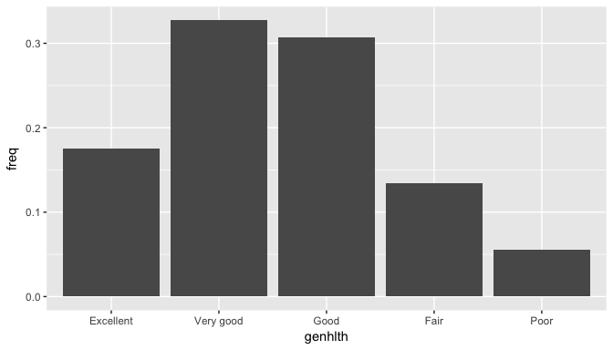

```r
sleep_clean %>% filter(!is.na(genhlth)) %>% group_by(genhlth) %>% summarise(n = n()) %>% mutate(freq = n/sum(n)) %>% ggplot(aes(x=genhlth, y=freq)) + geom_bar(stat = "identity")
```

“Very good” and “Good” make up the majority of the respondents’ statuses, each making up roughly a third.

As I want to break down the results by respondents’ sex, I will first examine the sex variable:

```r
sleep_clean %>% group_by(sex) %>% summarise(n = n())
```

```
## # A tibble: 3 x 2
##      sex      n
##   <fctr>  <int>
## 1   Male 198910
## 2 Female 285474
## 3   <NA>      1
```

There is 1 NA which appears to be a mistake, so I will remove this data point for this analysis.

I will now examine the frequency of each sex in the dataset:

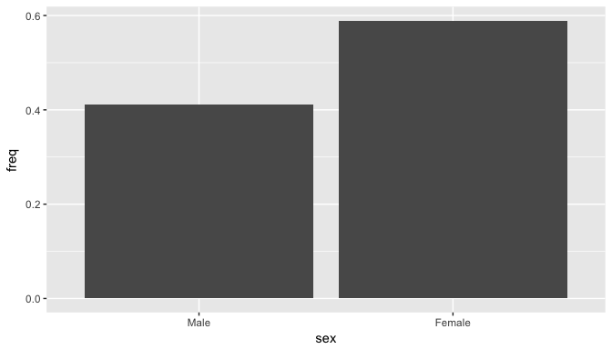

```r
sleep_clean %>% filter(!is.na(sex)) %>% group_by(sex) %>% summarise(n = n()) %>% mutate(freq = n/sum(n)) %>% ggplot(aes(x = sex, y = freq)) + geom_bar(stat= "identity")
```

```r
sleep_clean %>% filter(!is.na(sex)) %>% group_by(sex) %>% summarise(n = n()) %>% mutate(freq = n/sum(n))
```

```
## # A tibble: 2 x 3
##      sex      n      freq
##   <fctr>  <int>     <dbl>
## 1   Male 198910 0.4106453
## 2 Female 285474 0.5893547
```

The frequencies illustrate that there are more females than males in the dataset.

I will now examine the association between the range of hours of sleep repondents got vs. their reported health status in a segmented, relative frequency plot, broken down by sex:

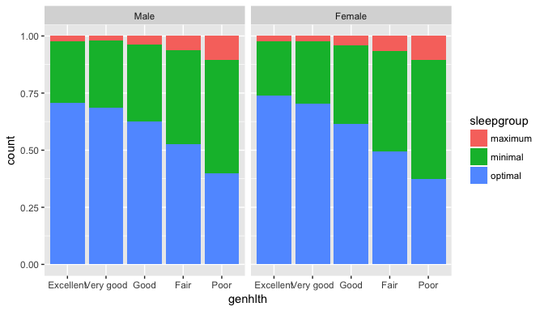

```r
sleep_clean %>% filter(!is.na(genhlth), !is.na(sex)) %>% ggplot(aes(x=genhlth, fill=sleepgroup)) + geom_bar(position = "fill") + facet_wrap(~sex)
```

This graph illustrates that there appears to be an association between the range of sleep hours and health status: as health status decreases, the proportion of respondents in the “optimal” range decreases, while the proportion of respondents in the “minimal” and “maximum” ranges increases. However, there does not appear to be a substantial difference between males and females in breakdown of sleep ranges by health status.

Further research into the significance of these associations and potential causual implications is warranted.

**Research Question 3:** Is there an association between the amount of exercise respondents partake in and both sex and overweight/obesity status?

I will begin by examining the exercise minutes in a boxplot and histogram:

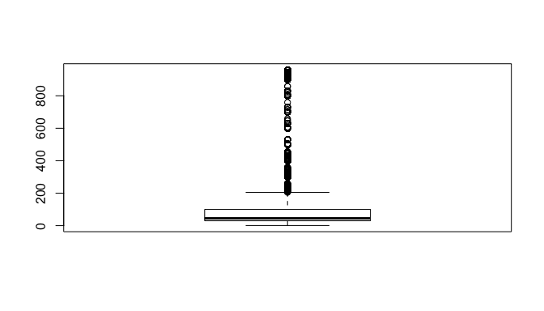

```r
boxplot(data = brfss2013, x=brfss2013$exerhmm1)
```

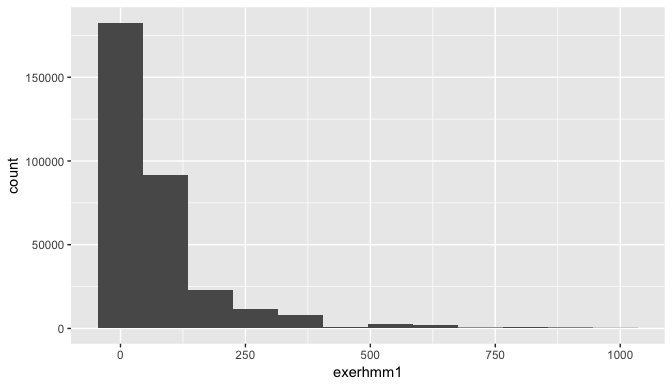

```r
ggplot(brfss2013, aes(x=exerhmm1)) + geom_histogram(binwidth = 90)
```

These graphs illustrate that the number of minutes respondents spent exercising (walking, running, jogging or swimming) is right skewed, with fewer and fewer people exercising for longer periods. Also, it is important to note that there was a high number of missing values for this variable.

```r
brfss2013 %>% filter(!is.na(exerhmm1)) %>% summarise(mean = mean(exerhmm1), median=median(exerhmm1), sd=sd(exerhmm1))
```

```
##       mean median       sd
## 1 92.94768     45 113.9811
```

The high standard deviation indicates that the spread of data is quite variable. Given the skewness, the median of 45 minutes is more meaningful than the mean, with 50% of respondents exercising this amount of time or less. Thus, I will examine the medians when exploring the relationship between exercise minutes and sex and overweight/obesity status.

I will also examine the breakdown of overweight/obese and non-overweight/obese respondents in the dataset with a frequency table and plot:

```r
brfss2013 %>% filter(!is.na(X_rfbmi5)) %>% group_by(X_rfbmi5) %>% summarise(n = n()) %>% mutate(freq = n/sum(n))
```

```
## # A tibble: 2 x 3
##   X_rfbmi5      n      freq
##     <fctr>  <int>     <dbl>
## 1       No 163161 0.3508492
## 2      Yes 301885 0.6491508
```

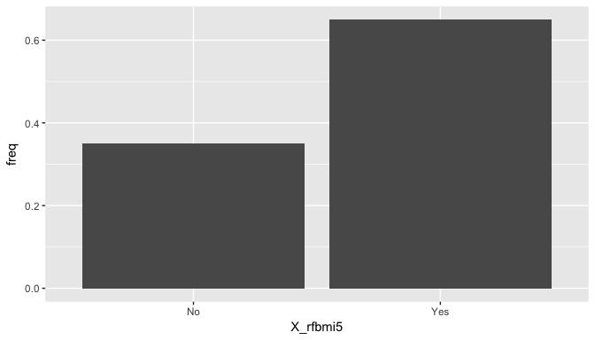

```r
brfss2013 %>% filter(!is.na(X_rfbmi5)) %>% group_by(X_rfbmi5) %>% summarise(n = n()) %>% mutate(freq = n/sum(n)) %>% ggplot(aes(x = X_rfbmi5, y = freq)) + geom_bar(stat= "identity")
```

The above table and graph illustrate that there are about a third non-overweight/obese respondents and about two-thirds overweight/obese respondents in the dataset.

I will now examine the association between exercise minutes and overweight/obesity status and sex in a clustered column chart:

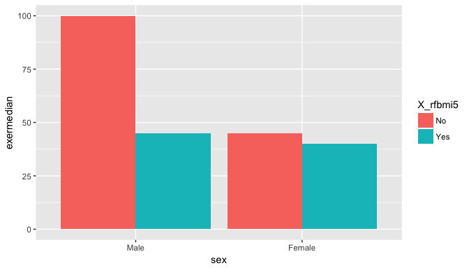

```r
 brfss2013  %>% filter(!is.na(exerhmm1), !is.na(X_rfbmi5)) %>% group_by(sex, X_rfbmi5) %>% summarise (exermedian = median(exerhmm1)) %>% ggplot(aes(x=sex, y = exermedian, fill = X_rfbmi5)) + geom_bar(stat = "identity", position = "dodge")
```

```r
brfss2013  %>% filter(!is.na(exerhmm1), !is.na(X_rfbmi5)) %>% group_by(sex, X_rfbmi5) %>% summarise (exermedian = median(exerhmm1), count = n())
```

```
## # A tibble: 4 x 4
## # Groups:   sex [?]
##      sex X_rfbmi5 exermedian count
##   <fctr>   <fctr>      <dbl> <int>
## 1   Male       No        100 38650
## 2   Male      Yes         45 95919
## 3 Female       No         45 76740
## 4 Female      Yes         40 98550
```

The table and graph illustrate that within the male group, those who were not overweight/obese had a much higher median exercise time than those who were overweight/obese. Females did not show as dramatic a difference in exercise times between those who were overweight/obese and those who were not. Additionally, the median exercise time of males who were overweight/obese corresponded to the values in both weight groups of females. Thus, this data show that non-overweight/obese males exercise the most, while overweight/obese males and females of both weight groups appear to exercise the same amount. This suggests that there appears to be an association between exercise times and overweight/obesity status when examined by sex.

Further research into the significance of these associations and potential causual implications is warranted.